# барабулька

Задание 1. Загрузка данных

```python
import pandas as pd
import numpy as np
import matplotlib.pyplot as plt
```

Загружаем CSV-файл в DataFrame

```python
df = pd.read_csv('spotify_artist_streaming_2020_2025.csv')
```

Выводим сообщение об успешной загрузке

```python
print("Данные успешно загружены!")
```

```
Данные успешно загружены!
```

Задание 2. Первичное знакомство с датасетом

```python
print("Первые 5 и последние 5 строк датасета")
display(df)
```

```
Первые 5 и последние 5 строк датасета
```

|  | track_id | track_name | artist_name | album_name | release_date | genre | duration_ms | popularity | danceability | energy | ... | popularity_category | loudness_category | key_name | mode_name | is_explicit_bool | release_quarter | is_weekend_release | log_stream_count | upbeat_score | artist_track_count |
| --- | --- | --- | --- | --- | --- | --- | --- | --- | --- | --- | --- | --- | --- | --- | --- | --- | --- | --- | --- | --- | --- |
| 0 | 346d85e2-ffde-41b3-854a-589ed880b91f | Storm | Ethereal | The Hollow Journeys | 2021-10-06 | Pop | 169594 | 47 | 0.6777 | 0.7949 | ... | Medium | Loud | A | Major | False | Q4 | False | 10.7492 | 0.6632 | 3232 |
| 1 | 12bc268a-363b-4f19-8fa8-0ced7ae1e462 | Silent | The Wolfs | Ancient Thunder | 2024-10-26 | K-Pop | 256755 | 26 | 0.9405 | 0.7163 | ... | Medium | Moderate | C# | Major | False | Q4 | True | 8.5895 | 0.7615 | 20 |
| 2 | 30d627d9-878d-4bb3-be59-71feb6ed4f3f | Shattered Lines | LolaOre | Twisted Harbors | 2022-11-12 | Punk | 170212 | 46 | 0.6853 | 0.9500 | ... | Medium | Loud | E | Major | False | Q4 | True | 12.2935 | 0.7828 | 199 |
| 3 | 85501bb9-d221-4339-9e2e-29b1b3daff0a | Breaking Roses | Clay Black | The Blinding Letters | 2020-06-22 | Pop | 181250 | 4 | 0.7817 | 0.6943 | ... | Low | Moderate | F# | Major | False | Q2 | False | 8.5658 | 0.6778 | 693 |
| 4 | 7bf92bd2-c6fe-4869-a90e-242bb8bbe7a3 | Lines | Knot Hart | The Cosmic Letters | 2024-01-22 | Latin | 160894 | 27 | 0.7200 | 0.4958 | ... | Medium | Moderate | C# | Major | False | Q1 | False | 10.2191 | 0.5494 | 12111 |
| ... | ... | ... | ... | ... | ... | ... | ... | ... | ... | ... | ... | ... | ... | ... | ... | ... | ... | ... | ... | ... | ... |
| 49995 | 38913908-e3ab-42a2-9a97-2d1847c21e3b | Flames | Luna Ink | The Shattered Tapes | 2025-02-27 | Hip-Hop | 249380 | 6 | 0.7338 | 0.8172 | ... | Low | Loud | C# | Major | False | Q1 | False | 6.2005 | 0.7545 | 577 |
| 49996 | 83653402-ca85-4583-b7ec-13ab3e82888e | Love | Knot Hart | Young II | 2021-07-25 | Folk | 176329 | 22 | 0.5547 | 0.0000 | ... | Low | Quiet | A# | Minor | True | Q3 | True | 9.1916 | 0.3292 | 12111 |
| 49997 | 4398dd33-ecfc-4c1a-ab9e-248f38082318 | The Waves | Jasper Jade | The Burning Journeys | 2023-12-24 | Pop | 202472 | 5 | 0.6558 | 0.8805 | ... | Low | Moderate | G | Major | True | Q4 | True | 7.8200 | 0.6794 | 181 |
| 49998 | 07c673e7-39a5-4c28-8789-163ae5f17f3f | Flying Eyes | ElaraRain | Frequencies | 2020-08-17 | Rock | 172542 | 81 | 0.5979 | 0.6252 | ... | Very High | Moderate | F# | Minor | False | Q3 | False | 15.1911 | 0.5622 | 1111 |
| 49999 | 888e233c-e7fd-4c0d-af8a-3cd98345a64e | Roads | Edge Brooks | Wicked III | 2020-11-19 | Hip-Hop | 198469 | 27 | 0.9388 | 0.6830 | ... | Medium | Moderate | G# | Minor | True | Q4 | False | 9.3957 | 0.7795 | 65 |

50000 rows × 33 columns

Определяем количество строк и столбцов

```python
print(f"Размер датасета: {df.shape[0]} строк, {df.shape[1]} столбцов")
```

```
Размер датасета: 50000 строк, 33 столбцов
```

Выводим названия всех столбцов

```python
print("Названия столбцов:")
print(df.columns.tolist())
```

[output not shown]

Смотрим типы данных столбцов

```python
print("Типы данных столбцов:")
print(df.dtypes)
```

```
Типы данных столбцов:
track_id                object
track_name              object
artist_name             object
album_name              object
release_date            object
genre                   object
duration_ms              int64
popularity               int64
danceability           float64
energy                 float64
key                      int64
loudness               float64
mode                     int64
instrumentalness       float64
tempo                  float64
stream_count             int64
country                 object
explicit                  bool
label                   object
release_year             int64
release_month            int64
release_day_of_week     object
duration_minutes       float64
popularity_category     object
loudness_category       object
key_name                object
mode_name               object
is_explicit_bool          bool
release_quarter         object
is_weekend_release        bool
log_stream_count       float64
upbeat_score           float64
artist_track_count       int64
dtype: object
```

Задание 3. Сортировка данных

```python
print("Топ-10 треков по прослушиваниям")
```

```
Топ-10 треков по прослушиваниям
```

```python
top_tracks = df.nlargest(10, 'stream_count')
print("Топ-10 треков:")
print(top_tracks[['artist_name', 'track_name', 'genre', 'stream_count']])
```

```
Топ-10 треков:
       artist_name        track_name        genre  stream_count
1528    Grove Nova         The Roses  Alternative      43345015
36998  Flora Quinn            Bitter         Rock      26635547
42813     Ethereal       The Streets          Pop      26314312
21643    SethStone  Breaking Thunder        Metal      20408155
49193     IsleEyre         The Pages          Pop      19265301
26622  Dean System            Lights      Hip-Hop      17238449
45015    Rocco Ore            Gentle          R&B      15776187
39012    Knot Hart             Storm          R&B      14545933
29091     The Inks   Burning Islands          Pop      14507867
13635   Prism Hart       Broken Eyes          R&B      14367106
```

Ответы на вопросы

```python
print("Исполнители в топ-10:")
print(top_tracks['artist_name'].value_counts())
```

```
Исполнители в топ-10:
artist_name
Grove Nova     1
Flora Quinn    1
Ethereal       1
SethStone      1
IsleEyre       1
Dean System    1
Rocco Ore      1
Knot Hart      1
The Inks       1
Prism Hart     1
Name: count, dtype: int64
```

```python
print("Жанры в топ-10:")
print(top_tracks['genre'].value_counts())
```

```
Жанры в топ-10:
genre
Pop            3
R&B            3
Alternative    1
Rock           1
Metal          1
Hip-Hop        1
Name: count, dtype: int64
```

Задание 4. Фильтрация

Находим треки после 2024 года

```python
tracks_after_2024 = df[df['release_year'] > 2024]
print(f"Треков после 2024 года: {len(tracks_after_2024)}")
print("Первые 5 треков после 2024:")
print(tracks_after_2024[['track_name', 'artist_name', 'release_year']].head())
```

```
Треков после 2024 года: 8318
Первые 5 треков после 2024:
        track_name   artist_name  release_year
6            Skies     Knot Hart          2025
14       The Roads     Knot Hart          2025
17  Liquid Streets     ElaraRain          2025
18   Broken Ghosts  Sterling Zen          2025
24       The Tears  Sterling Zen          2025
```

Задание 5. Основные статистические показатели

Находим среднее и медиану для popularity

```python
mean_popularity = df['popularity'].mean()
median_popularity = df['popularity'].median()
print(f"Среднее popularity: {mean_popularity:.2f}")
print(f"Медиана popularity: {median_popularity:.2f}")
```

```
Среднее popularity: 28.14
Медиана popularity: 26.00
```

Находим минимум, максимум и стандартное отклонение для popularity

```python
min_popularity = df['popularity'].min()
max_popularity = df['popularity'].max()
std_popularity = df['popularity'].std()
print(f"Минимальное popularity: {min_popularity}")
print(f"Максимальное popularity: {max_popularity}")
print(f"Стандартное отклонение popularity: {std_popularity:.2f}")
```

```
Минимальное popularity: 0
Максимальное popularity: 92
Стандартное отклонение popularity: 16.00
```

Объяснение:

```python
print("Объяснение статистик:")
print("Среднее арифметическое - сумма всех значений, деленная на их количество")
print("Медиана - значение, которое делит упорядоченный ряд пополам")
print("Минимум - наименьшее значение в наборе данных")
print("Максимум - наибольшее значение в наборе данных")
print("Стандартное отклонение - мера разброса данных относительно среднего")
```

```
Объяснение статистик:
Среднее арифметическое - сумма всех значений, деленная на их количество
Медиана - значение, которое делит упорядоченный ряд пополам
Минимум - наименьшее значение в наборе данных
Максимум - наибольшее значение в наборе данных
Стандартное отклонение - мера разброса данных относительно среднего
```

Задание 6. Мода

Находим моду для genre

```python
genre_mode = df['genre'].mode()
print("Мода для столбца genre:")
print(f"Наиболее частый жанр: {genre_mode.iloc[0] if not genre_mode.empty else 'Нет данных'}")
```

```
Мода для столбца genre:
Наиболее частый жанр: R&B
```

Находим моду для release_year

```python
year_mode = df['release_year'].mode()
print("Мода для столбца release_year:")
print(f"Наиболее частый год выпуска: {year_mode.iloc[0] if not year_mode.empty else 'Нет данных'}")
```

```
Мода для столбца release_year:
Наиболее частый год выпуска: 2024
```

Задание 7. Гистограмма

Строим гистограмму распределения popularity

Добавляем заголовок и подписи осей

Добавляем сетку

Отображаем график

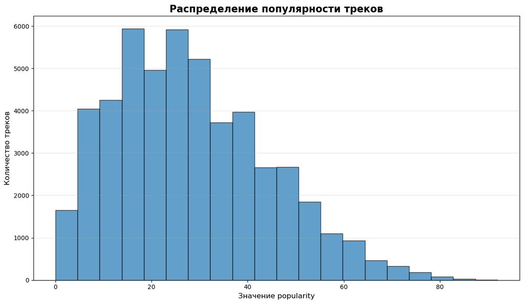

```python
plt.figure(figsize=(12, 7))
plt.hist(df['popularity'], bins=20, edgecolor='black', alpha=0.7)
plt.title('Распределение популярности треков', fontsize=16, fontweight='bold')
plt.xlabel('Значение popularity', fontsize=12)
plt.ylabel('Количество треков', fontsize=12)
plt.grid(axis='y', alpha=0.3)
plt.tight_layout()
plt.show()
```

Дополнительная статистика для подтверждения

```python
print(f"Дополнительная статистика popularity:")
print(df['popularity'].describe())
```

```
Дополнительная статистика popularity:
count    50000.000000
mean        28.136820
std         15.999501
min          0.000000
25%         16.000000
50%         26.000000
75%         39.000000
max         92.000000
Name: popularity, dtype: float64
```

Ответы на контрольные вопросы

1. Что такое DataFrame?

DataFrame - это двумерная структура данных в библиотеке Pandas, которая представляет собой таблицу с строками и столбцами. Каждый столбец может содержать данные разных типов, а строки индексируются.

2. Что такое признак (Feature)?

Признак (Feature) - это отдельная характеристика или атрибут объекта в наборе данных. В нашем случае признаками являются: artist_name, track_name, genre, popularity, stream_count, release_year и другие характеристики треков.

3. Чем среднее арифметическое отличается от медианы?

Среднее арифметическое - это сумма всех значений, деленная на их количество. Оно чувствительно к выбросам и аномалиям в данных. Медиана - это значение, которое находится в центре упорядоченного ряда данных. Она устойчива к выбросам и лучше отражает типичное значение при асимметричном распределении.

4. Что показывает гистограмма?

Гистограмма показывает распределение значений числовой переменной. Она группирует данные в интервалы (корзины) и показывает частоту попадания значений в каждый интервал. Позволяет оценить форму распределения, наличие выбросов и основные диапазоны значений.

5. Для чего нужна фильтрация данных?

Фильтрация данных нужна для: Выделения подмножества данных по определенным условиям Анализа конкретных групп объектов (например, треки после 2024 года) Удаления шума и нерелевантных данных Подготовки данных для дальнейшего анализа или визуализации